# Analysis for OJS Global Paper

Saurabh Khanna, Jon Ball, Juan Pablo Alperin, John Willinsky

Updated: October 20, 2022

Current preprint available [here](https://preprints.scielo.org/index.php/scielo/preprint/view/4729).

## Loading and cleaning beacon data

```r
# Libraries
pacman::p_load(tidyverse, countrycode, sf, state, htmltools, htmlwidgets, urltools, janitor, DT, RColorBrewer, plotly, readxl, rvest)

# raw beacon data
df <- read_csv(here::here("data/beacon-public.csv"))

# ancillary data and vectors for cleaning and plotting
iso_to_name <- read_csv(here::here("data/country-iso3166-to-name.csv"))

canada.states <-
  c(
    "Alberta", "British Columbia", "Labrador", "Manitoba", "New Brunswick", "Newfoundland", "Nova Scotia", "Nunavut", "North West Terr.", "Ontario", "Prince Edward Is.", "Québec (Province)", "Saskatchewan", "Yukon"
  )

# world map shapefile
shapefile <-
  read_sf(here::here("data/TM_WORLD_BORDERS_SIMPL-0.3.shp")) %>%
  clean_names() %>%
  filter(name %in% c("Western Sahara", "Morocco")) %>% # handling boundary issues for morocco and western sahara
  mutate(name = if_else(name == "Western Sahara", "Morocco", name)) %>%
  arrange(name) %>%
  group_by(name) %>%
  summarize(
    geometry = st_union(geometry),
    lat = first(lat),
    lon = first(lon),
    region = first(region),
    subregion = first(subregion)
  ) %>%
  st_cast("MULTIPOLYGON") %>%
  bind_rows(
    read_sf(here::here("data/TM_WORLD_BORDERS_SIMPL-0.3.shp")) %>%
      clean_names() %>%
      filter(!(name %in% c("Western Sahara", "Morocco")))
  )
```

```r
# Cleaning oai urls
df <-
  df %>%
  mutate(oai_url = if_else(str_detect(oai_url, "^//"), str_c("http:", oai_url), oai_url))


# Getting domain, tld, and merging in country names
df <-
  bind_cols(
    df,
    df %>% pull(oai_url) %>% domain() %>% tld_extract()
  ) %>%
  mutate(country_consolidated = str_to_lower(country_consolidated) %>% str_trim()) %>%
  left_join(iso_to_name, by = c("country_consolidated" = "tld"))


# Cleaning country names
df <-
  df %>%
  mutate(
    country = country_clean,
    country = if_else(country == "Washington (State)", "United States", country),
    country = if_else(str_detect(country, "United States|New York|District of Columbia"), "United States", country),
    country = if_else(country %in% state.name, "United States", country),
    country = if_else(country %in% canada.states, "Canada", country),
    country = if_else(str_detect(country, "China"), "China", country),
    country = if_else(str_detect(country, "Armenia"), "Armenia", country),
    country = if_else(str_detect(country, "Georgia"), "Georgia", country),
    country = if_else(str_detect(country, "Australia|New South Wales|Queensland|Victoria"), "Australia", country),
    country = if_else(str_detect(country, "England|British"), "United Kingdom", country),
    country = if_else(str_detect(country, "Russia|Soviet Union"), "Russia", country),
    country = if_else(str_detect(country, "Palestine"), "Palestine", country),
    country = if_else(country == "Korea (South)", "South Korea", country)
  ) %>%
  select(-country_clean, -country_marc, -country_issn, -country_tld, -country_ip)


# Mapping countries to continents
continents <-
  df %>%
  pull(country) %>%
  countrycode(origin = "country.name", destination = "continent")

df <- df %>% bind_cols(continents)

# Rename last column to `continent`
names(df)[length(names(df))] <- "continent"
```

```r
# Filter to active OJS journals
df <-
  df %>%
  filter(application == "ojs", record_count_2020 >= 5) %>%
  distinct(oai_url, repository_name, set_spec, .keep_all = T)
```

Total active journals using OJS (JUOJS):

```r
df %>% count()
```

| n |
| --- |
| 25671 |

Total articles published in active JUOJS:

```r
df %>% summarise(total = sum(record_count_2020, na.rm = T))
```

| total |
| --- |
| 996405 |

Average articles published in active JUOJS:

```r
df %>% summarise(total = mean(record_count_2020, na.rm = T))
```

| total |
| --- |
| 38.81442 |

Total distinct ISSNs:

```r
df %>%
  mutate(
    issn = str_extract(issn, "[^\n]+") # correcting for multiple reported issns
  ) %>%
  distinct(issn) %>%
  drop_na(issn) %>%
  count()
```

| n |
| --- |
| 22809 |

## JUOJS Global Presence in 2020

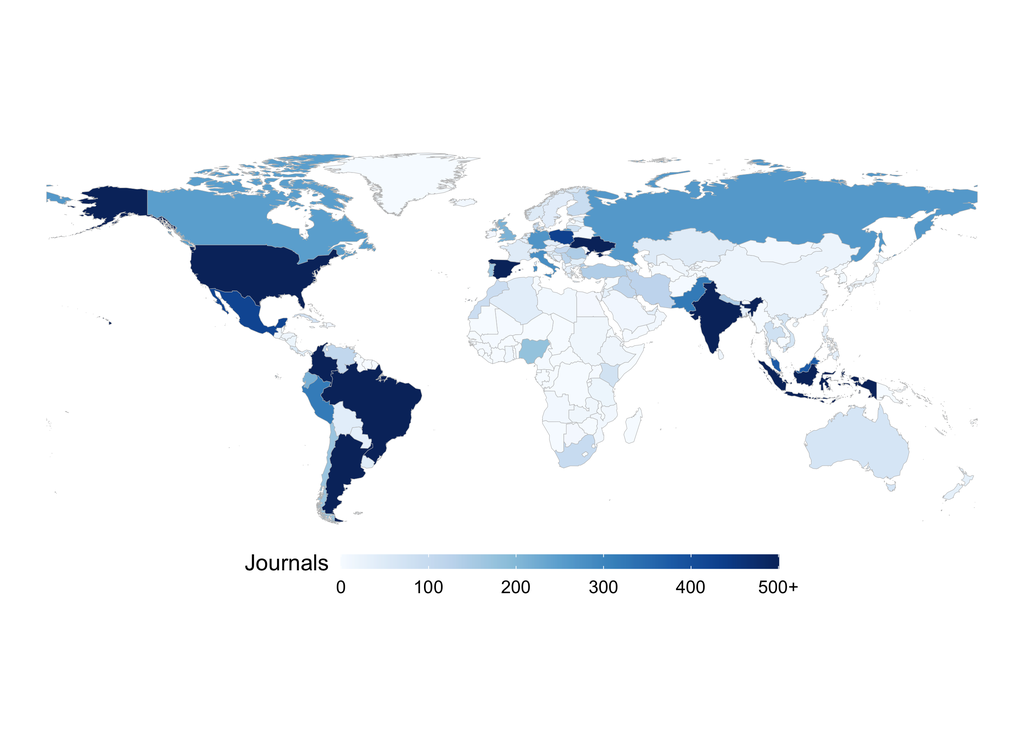

```r
# global df
df_world <-
  df %>%
  drop_na(country) %>%
  count(country, name = "total")

labels <- function(x) {
  if_else(x < 500, as.character(x), "500+")
}

shapefile %>%
  clean_names() %>%
  rename(country = name) %>%
  mutate(
    country = if_else(country == "Libyan Arab Jamahiriya", "Libya", country),
    country = if_else(country == "United Republic of Tanzania", "Tanzania", country),
    country = if_else(country == "Cote d'Ivoire", "Côte d'Ivoire", country),
    country = if_else(country == "Congo", "Republic of the Congo", country),
    country = if_else(country == "Viet Nam", "Vietnam", country),
    country = if_else(str_detect(country, "Iran"), "Iran", country),
    country = if_else(str_detect(country, "Korea, Republic of"), "South Korea", country),
    country = if_else(str_detect(country, "Korea, Democratic People's Republic of"), "North Korea", country),
    country = if_else(str_detect(country, "Surinam"), "Surinam", country)
  ) %>%
  left_join(df_world, by = "country") %>% #arrange(area) %>% select(country, total, area)
  filter(total > 0 | area > 1000) %>%
  filter(country != "Antarctica") %>%
  mutate(
    total = replace_na(total, 0),
    total = pmin(total, 500)
  ) %>%
  ggplot() +
  geom_sf(aes(fill = total), size = 0.1, color = "gray", show.legend = T) +
  scale_fill_gradientn(
    breaks = seq(0, 500, 100),
    labels = labels,
    colors = RColorBrewer::brewer.pal(n = 9, name = "Blues")
  ) +
  guides(
    fill =
      guide_colorbar(
        barheight = 0.5,
        barwidth = 15,
        title = "Journals",
        title.vjust = 1,
      )
  ) +
  theme_void() +
  theme(legend.position = "bottom")
```

## JUOJS Growth (2010-20)

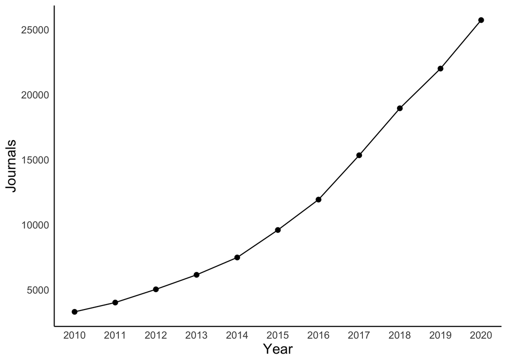

```r
 read_csv(here::here("data/beacon-public.csv")) %>%
  select(context_name, record_count_2010:record_count_2020) %>%
  pivot_longer(cols = starts_with("record_count")) %>%
  mutate(
    name = parse_number(name)
  ) %>%
  filter(value >= 5) %>%
  count(name) %>%
  mutate(name = as.integer(name)) %>%
  ggplot(aes(name, n)) +
  geom_line() +
  geom_point(size = 2) +
  theme_classic() +
  scale_x_continuous(breaks = seq(2010, 2020, 1)) +
  scale_y_continuous(breaks = seq(0, 25000, 5000)) +
  theme(
    axis.title = element_text(size = 14),
    axis.text = element_text(size = 10),
    axis.ticks = element_blank(),
    plot.title = element_text(hjust = 0.5)
  ) +
  labs(
    x = "Year",
    y = "Journals",
  )
```

## Assessing overlaps

### Web of Science

Total overlap:

```r
df_wos <-
  read_table(here::here("data/overlaps/wos.txt"), na = c("NULL", "NA", "")) %>%
  clean_names() %>%
  remove_empty() %>%
  filter(str_detect(issn, "^[0-9]{4}-[0-9]{3}[0-9xX]$")) %>%
  distinct(issn) %>%
  drop_na(issn)

# total overlap
df %>%
  mutate(
    issn = str_extract(issn, "[^\n]+")
  ) %>%
  inner_join(df_wos, by = "issn") %>%
  count()
```

| n |
| --- |
| 279 |

Top 10 countries in overlap:

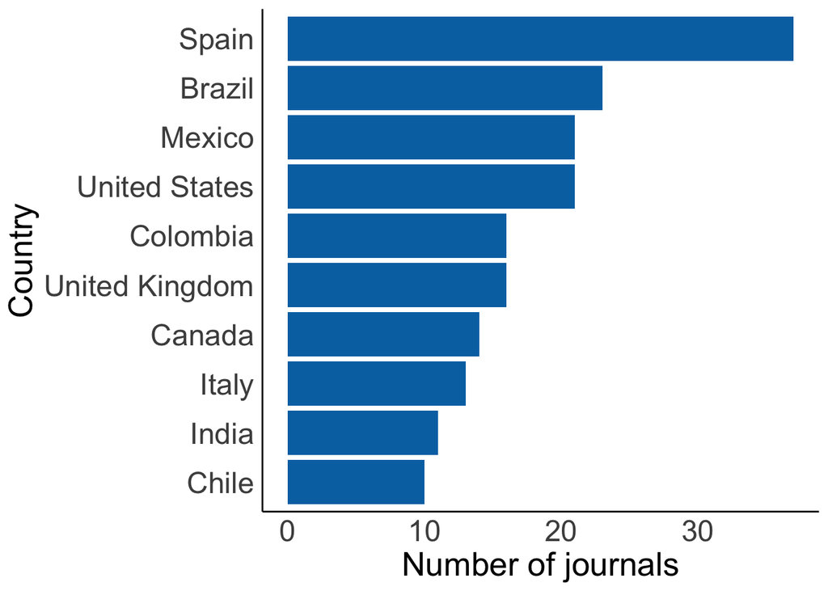

```r
# top 10 countries in overlap
df %>%
  mutate(
    issn = str_extract(issn, "[^\n]+")
  ) %>%
  inner_join(df_wos, by = "issn") %>%
  count(country) %>%
  arrange(-n) %>%
  head(10) %>%
  mutate(country = fct_inorder(country) %>% fct_rev()) %>%
  ggplot(aes(country, n)) +
  geom_col(fill = "#0072B2") +
  theme_classic() +
  theme(
    axis.title = element_text(size = 20),
    axis.text = element_text(size = 18),
    axis.ticks = element_blank()
  ) +
  coord_flip() +
  labs(
    x = "Country", y = "Number of journals"
  )
```

### Scopus

Total overlap:

```r
# Scopus data
df_scopus <-
  read_excel(here::here("data/overlaps/scopus.xlsx")) %>%
  clean_names() %>%
  remove_empty() %>%
  transmute(
    issn = str_replace(print_issn, "-", ""),
    e_issn = str_replace(e_issn, "-", "")
  ) %>%
  distinct() %>%
  remove_empty()

# join A (issn to issn)
df_join_a <-
  df %>%
  drop_na(issn) %>%
  transmute(
    country,
    issn = str_extract(issn, "[^\n]+"),
    issn = str_replace(issn, "-", "")
  ) %>%
  distinct(issn, .keep_all = T) %>%
  inner_join(df_scopus %>% select(-e_issn), by = "issn")

# join B (issn to e-issn)
df_join_b <-
  df %>%
  drop_na(issn) %>%
  transmute(
    country,
    issn = str_extract(issn, "[^\n]+"),
    issn = str_replace(issn, "-", "")
  ) %>%
  distinct(issn, .keep_all = T) %>%
  inner_join(df_scopus %>% select(-issn), by = c("issn" = "e_issn"))

bind_rows(df_join_a, df_join_b) %>%
  distinct() %>%
  count()
```

| n |
| --- |
| 1646 |

```r
# 1646/41957
# 1646/22809
```

Top 10 countries in overlap:

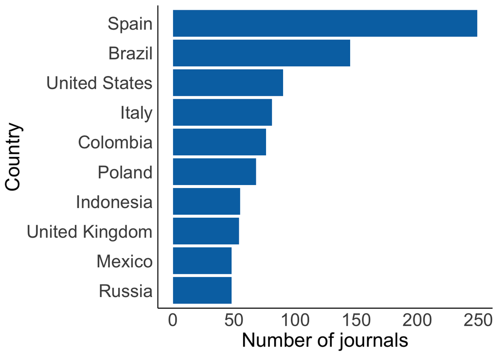

```r
bind_rows(df_join_a, df_join_b) %>%
  distinct() %>%
  drop_na(country) %>%
  count(country) %>%
  arrange(-n) %>%
  head(10) %>%
  mutate(country = fct_inorder(country) %>% fct_rev()) %>%
  ggplot(aes(country, n)) +
  geom_col(fill = "#0072B2") +
  theme_classic() +
  theme(
    axis.title = element_text(size = 20),
    axis.text = element_text(size = 18),
    axis.ticks = element_blank()
  ) +
  coord_flip() +
  labs(
    x = "Country", y = "Number of journals"
  )
```

### Dimensions

Total overlap:

```r
# Dimensions data
df_dimensions <-
  read_excel(here::here("data/overlaps/dimensions.xlsx")) %>%
  clean_names() %>%
  remove_empty() %>%
  transmute(
    issn = str_replace(issn_print, "-", "") %>% na_if("NULL"),
    e_issn = str_replace(issn_e, "-", "") %>% na_if("NULL")
  ) %>%
  distinct() %>%
  remove_empty()


# join A (issn to issn)
df_join_a <-
  df %>%
  drop_na(issn) %>%
  transmute(
    country,
    issn = str_extract(issn, "[^\n]+"),
    issn = str_replace(issn, "-", "")
  ) %>%
  distinct(issn, .keep_all = T) %>%
  inner_join(df_dimensions %>% select(-e_issn), by = "issn")

# join B (issn to e-issn)
df_join_b <-
  df %>%
  drop_na(issn) %>%
  transmute(
    country,
    issn = str_extract(issn, "[^\n]+"),
    issn = str_replace(issn, "-", "")
  ) %>%
  distinct(issn, .keep_all = T) %>%
  inner_join(df_dimensions %>% select(-issn), by = c("issn" = "e_issn"))

bind_rows(df_join_a, df_join_b) %>%
  distinct() %>%
  count()
```

| n |
| --- |
| 12435 |

```r
#12435/22809
#12435/72990
```

Top 10 countries in overlap:

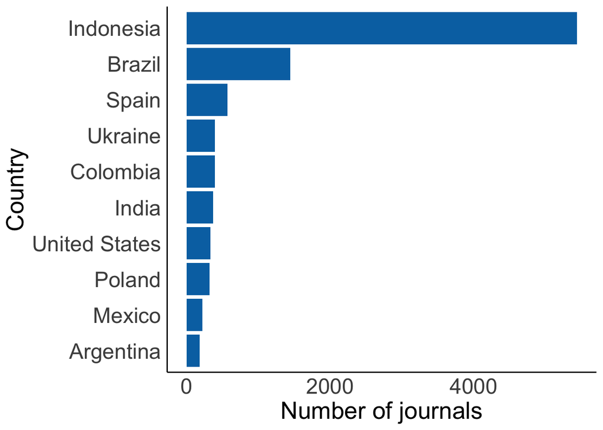

```r
bind_rows(df_join_a, df_join_b) %>%
  distinct() %>%
  drop_na(country) %>%
  count(country) %>%
  arrange(-n) %>%
  head(10) %>%
  mutate(country = fct_inorder(country) %>% fct_rev()) %>%
  ggplot(aes(country, n)) +
  geom_col(fill = "#0072B2") +
  theme_classic() +
  theme(
    axis.title = element_text(size = 20),
    axis.text = element_text(size = 18),
    axis.ticks = element_blank()
  ) +
  coord_flip() +
  labs(
    x = "Country", y = "Number of journals"
  )
```

### EBSCO Host

Total Overlap:

```r
# EBSCO Host
df_ebsco <-
  read_excel(here::here("data/overlaps/ebscohost.xls")) %>%
  clean_names() %>%
  remove_empty() %>%
  distinct(issn) %>%
  drop_na(issn)

df %>%
  drop_na(issn) %>%
  transmute(
    country,
    issn = str_extract(issn, "[^\n]+")
  ) %>%
  inner_join(df_ebsco, by = "issn") %>%
  count()
```

| n |
| --- |
| 771 |

Top 10 countries in overlap:

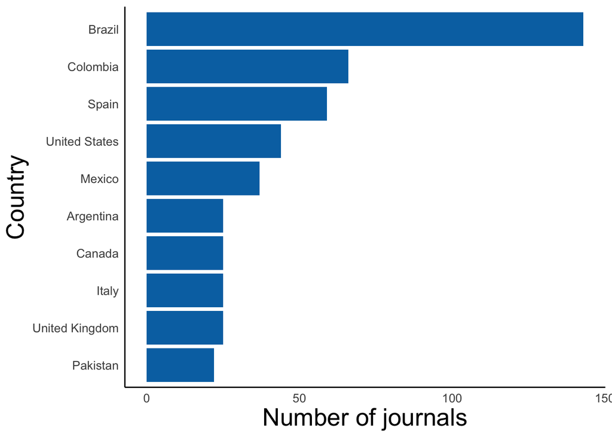

```r
df %>%
  drop_na(issn) %>%
  transmute(
    country,
    issn = str_extract(issn, "[^\n]+")
  ) %>%
  inner_join(df_ebsco, by = "issn") %>%
  drop_na(country) %>%
  count(country) %>%
  arrange(-n) %>%
  head(10) %>%
  mutate(country = fct_inorder(country) %>% fct_rev()) %>%
  ggplot(aes(country, n)) +
  geom_col(fill = "#0072B2") +
  coord_flip() +
  theme_classic() +
  theme(
    axis.title = element_text(size = 20),
    axis.text = element_text(size = 10),
    axis.ticks = element_blank()
  ) +
  labs(
    x = "Country", y = "Number of journals"
  )
```

### Google Scholar

```r
# Read in python processed google scholar URLs
## first iteration using journal URLs ##

df_gscholar <-
  read_csv(here::here("scripts/gscholar_urls_mapped.csv")) %>%
  select(-result_json) %>%
  mutate(n_results = parse_integer(n_results))

df_gscholar <-
  df %>%
  separate(oai_url, c("url1", "url2"), "\n") %>%
  remove_empty() %>%
  rename(oai_url = url1) %>%
  filter(!str_detect(oai_url, "\\?page=")) %>%
  transmute(
    country, total_record_count, context_name,
    url = str_replace(oai_url, "index/oai", set_spec),
    url = str_replace(url, "^https://", ""),
    url = str_replace(url, "^http://", ""),
    url = str_replace(url, "^www108.", ""),
    url = str_replace(url, "^www5.", ""),
    url = str_replace(url, "^www3.", ""),
    url = str_replace(url, "^www2.", ""),
    url = str_replace(url, "^www.", ""),
  ) %>%
  bind_rows(
    df %>%
      separate(oai_url, c("url1", "url2"), "\n") %>%
      remove_empty() %>%
      rename(oai_url = url1) %>%
      filter(str_detect(oai_url, "\\?page=")) %>%
      transmute(
        country, total_record_count, context_name,
        url = str_replace(oai_url, "oai$", set_spec),
        url = str_replace(url, "^https://", ""),
        url = str_replace(url, "^http://", ""),
        url = str_replace(url, "^www108.", ""),
        url = str_replace(url, "^www5.", ""),
        url = str_replace(url, "^www3.", ""),
        url = str_replace(url, "^www2.", ""),
        url = str_replace(url, "^www.", ""),
      ), .
  ) %>%
  distinct() %>%
  inner_join(df_gscholar, by = "url")


# bind_cols(
#     df_gscholar,
#     df_gscholar %>% pull(url) %>% domain() %>% tld_extract()
#   ) %>%
#   left_join(read_csv(here::here("scripts/gscholar_citations.csv")), by = "url") %>%
#   group_by(domain) %>%
#   summarise(
#     n_results = sum(n_results, na.rm = T),
#     n_citations = sum(n_citations, na.rm = T)
#   ) %>%
#   filter(n_results > 0) %>%
#   select(-n_results) %>%
#   write_csv(here::here("data/scholar_present_domains_set1.csv"))
```

Total overlap:

```r
# loading all domains
domains_in_scholar <-
  bind_rows(
    read_csv(here::here("data/scholar_present_domains_set1.csv")),
    read_csv(here::here("data/scholar_present_domains_set2.csv")),
  ) %>%
  distinct()

# total overlap
bind_cols(
    df_gscholar,
    df_gscholar %>% pull(url) %>% domain() %>% tld_extract()
  ) %>%
  inner_join(domains_in_scholar, by = "domain") %>%
  count()
```

| n |
| --- |
| 22679 |

```r
#22679/25671

#domains_in_scholar %>% summary()
#domains_in_scholar %>% filter(n_citations < 1)
#552/8548
```

Top 10 countries in overlap:

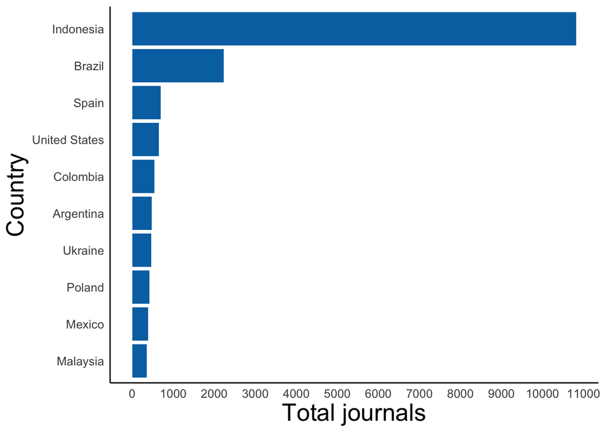

```r
# top 10 countries in overlap
bind_cols(
    df_gscholar,
    df_gscholar %>% pull(url) %>% domain() %>% tld_extract()
  ) %>%
  inner_join(domains_in_scholar, by = "domain") %>%
  count(country) %>%
  arrange(-n) %>%
  mutate(country = fct_inorder(country) %>% fct_rev()) %>%
  head(10) %>%
  ggplot(aes(country, n)) +
  geom_col(fill = "#0072B2") +
  scale_y_continuous(breaks = scales::breaks_width(1000)) +
  theme_classic() +
  theme(
    axis.title = element_text(size = 20),
    axis.text = element_text(size = 10),
    axis.ticks = element_blank()
  ) +
  coord_flip() +
  labs(x = "Country", y = "Total journals")
```

Number of citations on first Scholar page:

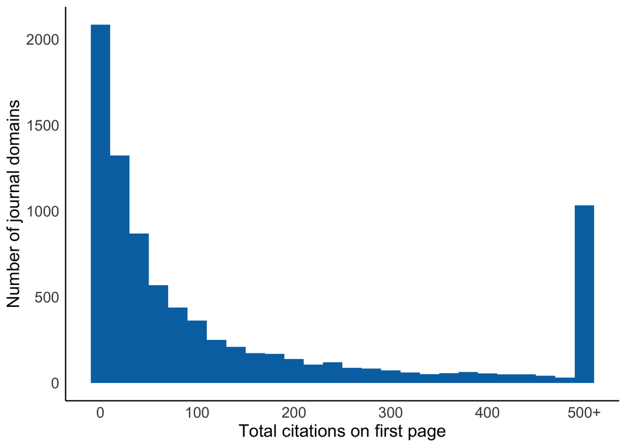

```r
# number of citations on first gscholar page
domains_in_scholar %>%
  mutate(n_citations = pmin(n_citations, 500)) %>%
  ggplot(aes(n_citations)) +
  geom_histogram(binwidth = 20, fill = "#0072B2") +
  scale_x_continuous(labels = c("0", "100", "200", "300", "400", "500+")) +
  hrbrthemes::theme_ipsum() +
  labs(
    x = "Total citations on first page",
    y = "Number of journal domains"
  ) +
  theme_classic() +
  theme(
    axis.title = element_text(size = 14),
    axis.text = element_text(size = 12),
    axis.ticks = element_blank()
  )
```

```r
# ggsave("scholar_citations.png")
```

Journals with non-zero citations on first page:

```r
# alter threshold to see proportions as needed (e.g. 0, 1000, 10000)
threshold <- 0

domains_in_scholar %>% arrange(-n_citations) %>% filter(n_citations > threshold) %>% count()
```

| n |
| --- |
| 7996 |

Summary of citations on first page:

```r
domains_in_scholar %>% summary()
```

```
##     domain           n_citations
##  Length:8548        Min.   :    0.0
##  Class :character   1st Qu.:   11.0
##  Mode  :character   Median :   50.0
##                     Mean   :  358.8
##                     3rd Qu.:  185.0
##                     Max.   :84656.0
```

### Latindex

Total Overlap:

```r
# Latindex
df_latindex <-
  read_excel(here::here("data/overlaps/latindex.xlsx")) %>%
  clean_names() %>%
  remove_empty() %>%
  select(issn, e_issn, online = en_linea) %>%
  distinct()


# join A (issn to issn)
df_join_a <-
  df %>%
  drop_na(issn) %>%
  transmute(
    country,
    issn = str_extract(issn, "[^\n]+")
  ) %>%
  distinct(issn, .keep_all = T) %>%
  inner_join(df_latindex %>% select(-e_issn), by = "issn")

# join B (issn to e-issn)
df_join_b <-
  df %>%
  drop_na(issn) %>%
  transmute(
    country,
    issn = str_extract(issn, "[^\n]+")
  ) %>%
  distinct(issn, .keep_all = T) %>%
  inner_join(df_latindex %>% select(-issn), by = c("issn" = "e_issn"))

bind_rows(df_join_a, df_join_b) %>%
  distinct() %>%
  arrange(country, issn, -online) %>%
  distinct(country, issn) %>%
  count()
```

| n |
| --- |
| 4208 |

```r
# 4208/24486
# 4208/6319
```

Top 10 countries in overlap:

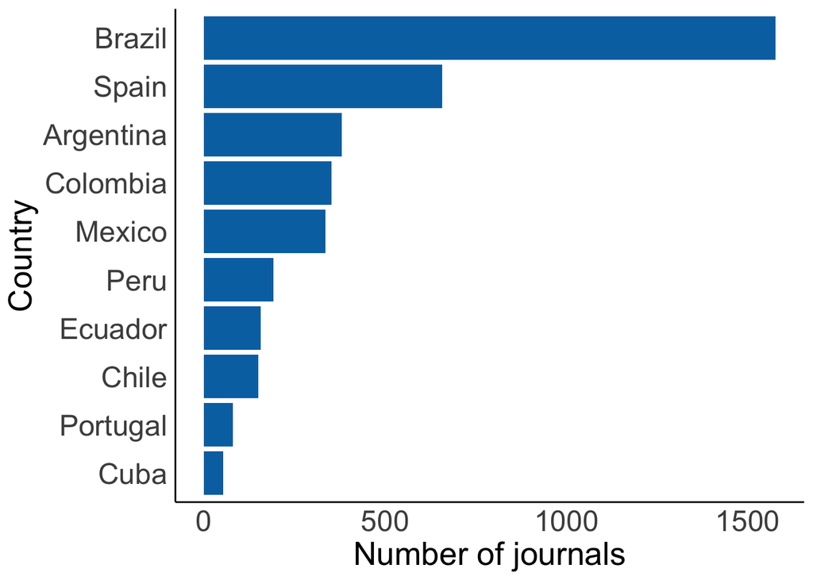

```r
bind_rows(df_join_a, df_join_b) %>%
  distinct() %>%
  arrange(country, issn, -online) %>%
  distinct(country, issn) %>%
  drop_na(country) %>%
  count(country) %>%
  arrange(-n) %>%
  head(10) %>%
  mutate(country = fct_inorder(country) %>% fct_rev()) %>%
  ggplot(aes(country, n)) +
  geom_col(fill = "#0072B2") +
  coord_flip() +
  labs(
    x = "Country", y = "Number of journals"
  ) +
  theme_classic() +
  theme(
    axis.title = element_text(size = 20),
    axis.text = element_text(size = 18),
    axis.ticks = element_blank()
  )
```

Latin American countries for JUOJS:

```r
# Latin American countries for JUOJS
df_latam <- read_csv(here::here("data/latindex_countries.csv"))

df %>%
  inner_join(df_latam, by = "country") %>%
  count()
```

| n |
| --- |
| 6319 |

## Citation analysis

### Top 100 cited journal domains

```r
df_lang_disc <-
  read_csv(here::here("data/OJS_languages_disciplines.csv")) %>%
  select(journal_url, language, discipline, journal_name = context_name) %>%
  remove_empty()

ojs_domains <-
  df %>%
  mutate(domain = str_remove_all(domain, "^www.")) %>%
  distinct(domain) %>%
  pull(domain) %>%
  suffix_extract() %>%
  transmute(domain = str_c(domain, suffix, sep = ".")) %>%
  distinct(domain) %>%
  pull(domain)


bind_cols(
  df_lang_disc,
  df_lang_disc %>% pull(journal_url) %>% domain() %>% tld_extract()
) %>%
  transmute(
    domain = str_replace(domain, "^https://", ""),
    domain = str_replace(domain, "^http://", ""),
    domain = str_replace(domain, "^www108.", ""),
    domain = str_replace(domain, "^www5.", ""),
    domain = str_replace(domain, "^www3.", ""),
    domain = str_replace(domain, "^www2.", ""),
    domain = str_replace(domain, "^www.", ""),
    language, discipline
  ) %>%
  distinct(domain, .keep_all = T) %>%
  inner_join(domains_in_scholar, by = "domain") %>%
  arrange(desc(n_citations)) %>%
  mutate(domain = str_c('<a href="http://', domain, '" target="_blank">', domain, '</a>')) %>%
  select(`Journal Domain` = domain, `Language` = language, `Discipline` = discipline, `Scholar First Page Citations` = n_citations) %>%
  head(100) %>%
  DT::datatable(escape = F, options = list(pageLength = 10))
```

|  | Journal Domain | Language | Discipline | Scholar First Page Citations |
| --- | --- | --- | --- | --- |
| 1 | aaai.org | English | Information and Computing Sciences | 84656 |
| 2 | jstatsoft.org | English | Mathematical Sciences | 59728 |
| 3 | journal.uny.ac.id | English | Education | 37380 |
| 4 | revistas.unal.edu.co | Spanish | History and Archaeology | 33799 |
| 5 | periodicos.ufsc.br | Portuguese | Language, Communication and Culture | 33678 |
| 6 | revistas.um.es | English | Biological Sciences | 31101 |
| 7 | journal.unnes.ac.id | English | Education | 26585 |
| 8 | periodicos.sbu.unicamp.br | English | Medical and Health Sciences | 26449 |
| 9 | bibliotecadigital.fgv.br | English | Commerce, Management, Tourism and Services | 26100 |
| 10 | revistas.ufpr.br | Portuguese | Medical and Health Sciences | 25690 |

[output cut: 90 more lines]

### Analysing citations for the Journal of Statistical Software (English)

- The journal domain is hosted [here](https://www.jstatsoft.org/index).
- The top citations for this journal’s most cited article is [here](https://scholar.google.com/scholar?cites=3069375885583311800&as_sdt=2005&sciodt=0,5&hl=en&inst=5746887945952177237).

```r
process_html <- function(html_content) {
  df_mini <-
    tibble(
      article = html_content %>%
        html_nodes(".gs_ri .gs_rt a") %>%
        html_text(),
      domain = html_content %>%
        html_nodes(".gs_ri .gs_rt a") %>%
        html_attr("href") %>%
        domain() %>%
        suffix_extract() %>%
        transmute(domain = str_c(domain, suffix, sep = ".")) %>%
        pull(domain),
      # citations = html_content %>%
      #   html_nodes(".gs_ri .gs_fl a") %>%
      #   html_text() %>%
      #   str_subset("^Cited by ") %>%
      #   parse_number()
    ) %>%
    mutate(
      domain_in_ojs = if_else(domain %in% ojs_domains, "Yes", "No"),
      domain = if_else(domain == "google.com", "books.google.com", domain)
    ) %>%
    # arrange(desc(citations)) %>%
    clean_names(case = "title") %>%
    rename(`JUOJS Domain` = `Domain in Ojs`, `Article/Book` = `Article`)

  return(df_mini)
}
```

```r
html_content1 <- read_html("https://scholar.google.com/scholar?cites=3069375885583311800&as_sdt=2005&sciodt=0,5&hl=en&inst=574688794952177237")
html_content2 <- read_html("https://scholar.google.com/scholar?start=10&hl=en&as_sdt=2005&sciodt=0,5&cites=3069375885583311800&scipsc=&inst=5746887945952177237")
html_content3 <- read_html("https://scholar.google.com/scholar?start=20&hl=en&as_sdt=2005&sciodt=0,5&cites=3069375885583311800&scipsc=&inst=5746887945952177237")
html_content4 <- read_html("https://scholar.google.com/scholar?start=30&hl=en&as_sdt=2005&sciodt=0,5&cites=3069375885583311800&scipsc=&inst=5746887945952177237")
html_content5 <- read_html("https://scholar.google.com/scholar?start=40&hl=en&as_sdt=2005&sciodt=0,5&cites=3069375885583311800&scipsc=&inst=5746887945952177237")
html_content6 <- read_html("https://scholar.google.com/scholar?start=50&hl=en&as_sdt=2005&sciodt=0,5&cites=3069375885583311800&scipsc=&inst=5746887945952177237")
html_content7 <- read_html("https://scholar.google.com/scholar?start=60&hl=en&as_sdt=2005&sciodt=0,5&cites=3069375885583311800&scipsc=&inst=5746887945952177237")
html_content8 <- read_html("https://scholar.google.com/scholar?start=70&hl=en&as_sdt=2005&sciodt=0,5&cites=3069375885583311800&scipsc=&inst=5746887945952177237")
html_content9 <- read_html("https://scholar.google.com/scholar?start=80&hl=en&as_sdt=2005&sciodt=0,5&cites=3069375885583311800&scipsc=&inst=5746887945952177237")
html_content10 <- read_html("https://scholar.google.com/scholar?start=90&hl=en&as_sdt=2005&sciodt=0,5&cites=3069375885583311800&scipsc=&inst=5746887945952177237")

bind_rows(
  `1` = process_html(html_content1),
  `2` = process_html(html_content2),
  `3` = process_html(html_content3),
  `4` = process_html(html_content4),
  `5` = process_html(html_content5),
  `6` = process_html(html_content6),
  `7` = process_html(html_content7),
  `8` = process_html(html_content8),
  `9` = process_html(html_content9),
  `10` = process_html(html_content10),
  .id = "Page"
) %>% view()
  write_csv(here::here("data/citation_samples/english.csv"))
```

```r
read_csv(here::here("data/citation_samples/english.csv")) %>%
  select(-Citations) %>%
  DT::datatable()
```

|  | Page | Article/Book | Domain | JUOJS Domain |
| --- | --- | --- | --- | --- |
| 1 | 1 | Principles and practice of structural equation modeling | books.google.com | No |
| 2 | 1 | A beginner's guide to structural equation modeling | taylorfrancis.com | No |
| 3 | 1 | Applying the Rasch model: Fundamental measurement in the human sciences | taylorfrancis.com | No |
| 4 | 1 | Latent variable models: An introduction to factor, path, and structural equation analysis | taylorfrancis.com | No |
| 5 | 1 | Flexible imputation of missing data | books.google.com | No |
| 6 | 1 | Structural equation modeling: Applications using Mplus | books.google.com | No |
| 7 | 1 | Multiple regression and beyond: An introduction to multiple regression and structural equation modeling | taylorfrancis.com | No |
| 8 | 1 | Common beliefs and reality about PLS: Comments on Rönkkö and Evermann (2013) | sagepub.com | No |
| 9 | 1 | piecewiseSEM: Piecewise structural equation modelling in r for ecology, evolution, and systematics | wiley.com | No |
| 10 | 1 | qgraph: Network visualizations of relationships in psychometric data | jstatsoft.org | Yes |

[output cut: 90 more lines]

JUOJS vs non-JUOJS domains among citations:

```r
read_csv(here::here("data/citation_samples/english.csv")) %>%
  count(`JUOJS Domain`, name = "Count")
```

| JUOJS Domain | Count |
| --- | --- |
| No | 95 |
| Yes | 5 |

### Analysing citations for the UNY Journal (Indonesian)

- The journal domain is hosted [here](https://journal.uny.ac.id/).
- The top citations for this journal’s most cited article is [here](https://scholar.google.com/scholar?cites=6422621221779132632&as_sdt=2005&sciodt=0,5&hl=en&inst=5746887945952177237).

```r
html_content1 <- read_html("https://scholar.google.com/scholar?cites=6422621221779132632&as_sdt=2005&sciodt=0,5&hl=en&inst=5746887945952177237")
html_content2 <- read_html("https://scholar.google.com/scholar?start=10&hl=en&as_sdt=2005&sciodt=0,5&cites=6422621221779132632&scipsc=&inst=5746887945952177237")
html_content3 <- read_html("https://scholar.google.com/scholar?start=20&hl=en&as_sdt=2005&sciodt=0,5&cites=6422621221779132632&scipsc=&inst=5746887945952177237")
html_content4 <- read_html("https://scholar.google.com/scholar?start=30&hl=en&as_sdt=2005&sciodt=0,5&cites=6422621221779132632&scipsc=&inst=5746887945952177237")
html_content5 <- read_html("https://scholar.google.com/scholar?start=40&hl=en&as_sdt=2005&sciodt=0,5&cites=6422621221779132632&scipsc=&inst=5746887945952177237")
html_content6 <- read_html("https://scholar.google.com/scholar?start=50&hl=en&as_sdt=2005&sciodt=0,5&cites=6422621221779132632&scipsc=&inst=5746887945952177237")
html_content7 <- read_html("https://scholar.google.com/scholar?start=60&hl=en&as_sdt=2005&sciodt=0,5&cites=6422621221779132632&scipsc=&inst=5746887945952177237")
html_content8 <- read_html("https://scholar.google.com/scholar?start=70&hl=en&as_sdt=2005&sciodt=0,5&cites=6422621221779132632&scipsc=&inst=5746887945952177237")
html_content9 <- read_html("https://scholar.google.com/scholar?start=80&hl=en&as_sdt=2005&sciodt=0,5&cites=6422621221779132632&scipsc=&inst=5746887945952177237")
html_content10 <- read_html("https://scholar.google.com/scholar?start=90&hl=en&as_sdt=2005&sciodt=0,5&cites=6422621221779132632&scipsc=&inst=5746887945952177237")

bind_rows(
  `1` = process_html(html_content1),
  `2` = process_html(html_content2),
  `3` = process_html(html_content3),
  `4` = process_html(html_content4),
  `5` = process_html(html_content5),
  `6` = process_html(html_content6),
  `7` = process_html(html_content7),
  `8` = process_html(html_content8),
  `9` = process_html(html_content9),
  `10` = process_html(html_content10),
  .id = "Page"
) %>%
  write_csv(here::here("data/citation_samples/indonesian.csv"))
```

```r
read_csv(here::here("data/citation_samples/indonesian.csv")) %>%
  DT::datatable()
```

|  | Page | Article/Book | Domain | JUOJS Domain |
| --- | --- | --- | --- | --- |
| 1 | 1 | Media pembelajaran | books.google.com | No |
| 2 | 1 | Modul virtual: Multimedia flipbook dasar teknik digital | upi.edu | Yes |
| 3 | 1 | Grup whatsapp sebagai media pembelajaran | archive.org | No |
| 4 | 1 | Pengembangan media pembelajaran pai berbasis lingkungan melalui model assure | iainponorogo.ac.id | Yes |
| 5 | 1 | Selection of Learning Media Mathematics for Junior School Students. | ed.gov | No |
| 6 | 1 | The problematics of Islamic religious education teacher in using of instructional media at SD Negeri 06 Pancung Soal Pesisir Selatan | tarbiyahiainib.ac.id | Yes |
| 7 | 1 | The criteria of learning media selection for character education in higher education | uinsgd.ac.id | Yes |
| 8 | 1 | Efektivitas penggunaan media pembelajaran permainan tradisional congklak untuk meningkatkan kemampuan berhitung pada siswa sekolah dasar | umm.ac.id | Yes |
| 9 | 1 | Pengaruh media pembelajaran terhadap mutu pembelajaran pada sekolah dasar terakreditasi A | academia.edu | No |
| 10 | 1 | Improving mathematical problem solving skills through visual media | iop.org | No |

[output cut: 87 more lines]

JUOJS vs non-JUOJS domains among citations:

```r
read_csv(here::here("data/citation_samples/indonesian.csv")) %>%
  count(`JUOJS Domain`, name = "Count")
```

| JUOJS Domain | Count |
| --- | --- |
| No | 26 |
| Yes | 71 |

### Analysing citations for Portal de Periodicos UFSC (Portuguese)

- The journal domain is hosted [here](https://periodicos.bu.ufsc.br/).
- The top citations for this journal’s most cited article is [here](https://scholar.google.com/scholar?cites=12229533173691059082&as_sdt=2005&sciodt=0,5&hl=en&inst=5746887945952177237).

```r
html_content1 <- read_html("https://scholar.google.com/scholar?cites=12229533173691059082&as_sdt=2005&sciodt=0,5&hl=en&inst=5746887945952177237")
html_content2 <- read_html("https://scholar.google.com/scholar?start=10&hl=en&as_sdt=2005&sciodt=0,5&cites=12229533173691059082&scipsc=&inst=5746887945952177237")
html_content3 <- read_html("https://scholar.google.com/scholar?start=20&hl=en&as_sdt=2005&sciodt=0,5&cites=12229533173691059082&scipsc=&inst=5746887945952177237")
html_content4 <- read_html("https://scholar.google.com/scholar?start=30&hl=en&as_sdt=2005&sciodt=0,5&cites=12229533173691059082&scipsc=&inst=5746887945952177237")
html_content5 <- read_html("https://scholar.google.com/scholar?start=40&hl=en&as_sdt=2005&sciodt=0,5&cites=12229533173691059082&scipsc=&inst=5746887945952177237")
html_content6 <- read_html("https://scholar.google.com/scholar?start=50&hl=en&as_sdt=2005&sciodt=0,5&cites=12229533173691059082&scipsc=&inst=5746887945952177237")
html_content7 <- read_html("https://scholar.google.com/scholar?start=60&hl=en&as_sdt=2005&sciodt=0,5&cites=12229533173691059082&scipsc=&inst=5746887945952177237")
html_content8 <- read_html("https://scholar.google.com/scholar?start=70&hl=en&as_sdt=2005&sciodt=0,5&cites=12229533173691059082&scipsc=&inst=5746887945952177237")
html_content9 <- read_html("https://scholar.google.com/scholar?start=80&hl=en&as_sdt=2005&sciodt=0,5&cites=12229533173691059082&scipsc=&inst=5746887945952177237")
html_content10 <- read_html("https://scholar.google.com/scholar?start=90&hl=en&as_sdt=2005&sciodt=0,5&cites=12229533173691059082&scipsc=&inst=5746887945952177237")

bind_rows(
  `1` = process_html(html_content1),
  `2` = process_html(html_content2),
  `3` = process_html(html_content3),
  `4` = process_html(html_content4),
  `5` = process_html(html_content5),
  `6` = process_html(html_content6),
  `7` = process_html(html_content7),
  `8` = process_html(html_content8),
  `9` = process_html(html_content9),
  `10` = process_html(html_content10),
  .id = "Page"
) %>%
  write_csv(here::here("data/citation_samples/portuguese.csv"))
```

```r
read_csv(here::here("data/citation_samples/portuguese.csv")) %>%
  DT::datatable()
```

|  | Page | Article/Book | Domain | JUOJS Domain |
| --- | --- | --- | --- | --- |
| 1 | 1 | O Corpo da roupa: a pessoa transgênera entre a transgressão ea coformidade com as normas de gênero | ufpr.br | Yes |
| 2 | 1 | Interfaces da vida loka: um estudo sobre jovens, tráfico de drogas e violência em São Paulo | neip.info | No |
| 3 | 1 | A nova polarização política nas eleições de 2014: radicalização ideológica da direita no mundo contemporâneo do Facebook | pucsp.br | Yes |
| 4 | 1 | O conceito de cogestão em saúde: reflexões sobre a produção de democracia institucional | scielo.br | Yes |
| 5 | 1 | Corpos, gêneros, sexualidades: políticas de subjetivação | academia.edu | No |
| 6 | 1 | Não apenas em nome de Deus: discursos religiosos sobre homossexualidade | scielo.br | Yes |
| 7 | 1 | Pausas do destino | books.google.com | No |
| 8 | 1 | Do controle social à gestão participativa: interrogações sobre a participação política no SUS | scielo.br | Yes |
| 9 | 1 | A noção de autor em Barthes, Foucault e Agamben | uesb.br | Yes |
| 10 | 1 | Crítica e metacrítica: contribuição e responsabilidade das teorias da comunicação | redalyc.org | No |

[output cut: 84 more lines]

JUOJS vs non-JUOJS domains among citations:

```r
read_csv(here::here("data/citation_samples/portuguese.csv")) %>%
  count(`JUOJS Domain`, name = "Count")
```

| JUOJS Domain | Count |
| --- | --- |
| No | 21 |
| Yes | 73 |